# Basics

## Histogram

In the probabilistic approach to classification, knowledge of density is all that is required to solve a classification problem. Knowledge of the true density is however rarely given, and one has to estimate the probability density function in feature space. The simplest way to visualize the probability density function in one or two dimensions is by constructing a histogram. The problem with histograms is choosing a suitable number of bins, wherefore if the number of bins is very small, useful information will be hidden, whereas if the number of bins is very large, then each bin may not contain enough samples for the histogram to be meaningful.

In all that follows, common alias names are used in the hints (e.g. np for numpy, pd for pandas, plt for matplotlib.pyplot, etc.)

**Exercise 1**. Generate a one dimensional dataset that is normally distributed using **np.random.normal()**. Let the number of samples be 1000 and plot the corresponding histogram using **plt.hist()** with the number of bins set to 10. Now change the number of bins from 10 to 100 and then to 1000. Which do you think is a more suitable choice?

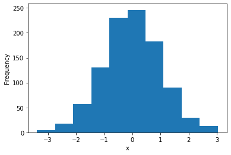

## Box Plot

A boxplot provides a way for visualizing data symbolically by summarizing a histogram plot. **plt.boxplot()** may be used for this purpose. A boxplot consists of a box with lines extended outward, the whiskers. The position of the box, whiskers, and other values are based on rank statistics obtained by the following procedure:

1. Data samples are sorted in ascending order.
2. The median is obtained; this is the 50th percentile.
3. The $r^{th}$ percentile is defined as the value at $(r/100) \times n$, where $n$ is the number of samples in the data.

**Exercise 2**. Boxplots are useful in that they capture in a single plot an estimate of the mean and statistics on how the data is spread. Why do you think rank statistics are used in these plots instead of mean and variance values?

**Exercise 3**. Use the function **np.random.normal()** to generate a one dimensional standard normal distribution (zero mean, unit variance) with 10,000 samples. Plot the 1D histogram and compute the mean and variance values using the functions **mean()** and **var()**. Finally construct a boxplot and compare the median value with the computed mean value.

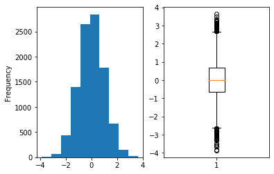

**Exercise 4**. Generate a skewed version, `b`, of the dataset `a` of the previous exercise, that is, let: **b = np.exp(-0.5*a)** and repeat the previous exercise.

## Scatter plot

Scatter plots are useful in visualizing data in the most intuitive manner: simply a plot of objects in feature space.

**Exercise 5**. Load the dataset 'boomerang3D.txt'. The dataset consists of two classes each with 500 samples in a 3-dimensional feature space. Set **plt.axes(projection='3d')** and create a 3D scatter plot (use the labels for color).

Rotate the figure; are the two classes separable? Use the function **plt.scatter()** to create a 2D scatter plot of the first feature against the second, then another 2D scatter plot of the first feature against the third, and finally a 2D scatter plot using the second and third features. From these plots, do the classes appear completely separable?

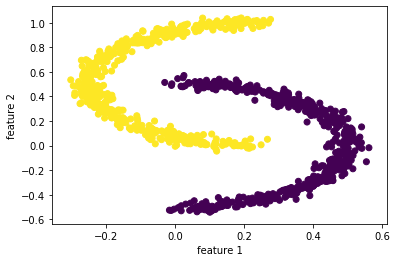

If the number of features exceeds three, then a single scatter plot is not feasible. In the case of high dimensions, a matrix of pair-wise scatter plots may be generated showing a scatter plot for every possible pair of features.

**Exercise 6**. Load the dataset 'dataset8D.txt'. The dataset consists of four classes each with 48 objects in an 8-dimensional feature space. Create a matrix of pair-wise scatter plots with **scatter_matrix()** from pandas. Make sure however not to include the labels column in these plots! What does the diagonal show in your case, and how would the plot look like otherwise? What can one deduce about features 5 and 6?

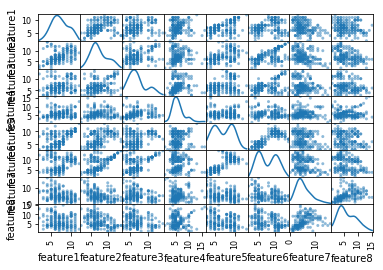

Find the covariance matrix of the dataset as follows:

```python
covmat = np.cov(data.iloc[:,:-1],rowvar=False).round(2)
covmat = np.cov(data.iloc[:,:-1].T).round(2)            #same
covmat = np.cov(data.drop(['label'],axis=1).T).round(2) #same
```

We may instead find the correlation matrix by replacing **np.cov()** with **np.corrcoef()** in the above code (alternatively you may use pandas' **corr()**). Moreover, we can visualize the correlation matrix as a heatmap using **plt.imshow(...,cmap='hot')**. You can also add a colorbar using **plt.colorbar()**. Try it out to obtain the image below. Do these matrices validate your observation about features 5 and 6?

To create the same labels as below, you may use **plt.yticks()** and **plt.xticks()** with a rotation set for the latter.

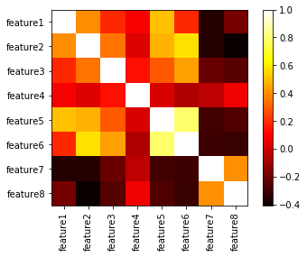

## Central Limit Theorem

The normal or Gaussian distribution is widely used and is found in many statistical distributions in nature. The central limit theorem provides an explanation for this fact. It states that the mean (or sum) of a large number of identically and independently distributed samples taken randomly from any distribution with mean $u$ and variance $v$ will follow approximately a Gaussian distribution. As the number of samples $n$ increases, the distribution of the mean approaches exactly the Gaussian distribution with mean $u$ and variance $v/n$. Since measured quantities in the real world are usually a sum of numerous unobserved random quantities coming from similar distributions, the central limit theorem helps explain why the measured quantity usually ends up following a normal distribution.

**Exercise 7**. Generate a hundred samples randomly from a 1D uniform distribution having values between 0 and 1 using **np.random.uniform()**. Compute the mean and variance of the data using **mean()** and **var()**. Repeat this 1000 times in a `for` loop and store the mean values. Plot a histogram of these values. Does the histogram resemble a familiar distribution? Compute the mean and variance of the stored values. How do these compare with the mean and variance values of the uniform distribution? Repeat the experiment with $n$ = 10 and 1000 samples instead of 100. What are the mean and variance values now? Is this in agreement with the central limit theorem?

## Parameter Estimation

In data analytics problems, we often employ training sets and test sets especially for assessing classification. It is often not acceptable to report a value based on a single experiment. In general, when estimating a parameter or reporting a value in any kind of report it should be standard practice to repeat an experiment if possible a number of times to obtain a fair estimate and an overview of the spread of the value estimated. In what follows we shall illustrate this concept by estimating the mean and variance of a predefined dataset.

**Exercise 8**. Consider a 1D normally distributed dataset with zero mean and unit variance. Let the number of samples be $n$. Then for each case of $n$ = 10, 50, 100, 250, 500, 1000 create a thousand such datasets and estimate for each dataset $i$ the mean value $m(i)$ and variance $v(i)$. Then calculate the mean `mean_m`, `mean_v` and standard deviation `sd_m`, `sd_v` of $m$ and $v$, and plot the values as a function of $n$ using the an errorbar plot, i.e. using **plt.errorbar()**. Example: one plot shown below.

How does the standard deviation of the mean estimate change as $n$ increases? From the plot you generated, how many samples do you think are required in order to estimate the mean and variance of a 1D normal distribution in a reliable manner?

Remember that using error bars (or otherwise confidence intervals) gives an indication of uncertainty which should be standard practice when reporting measurements.

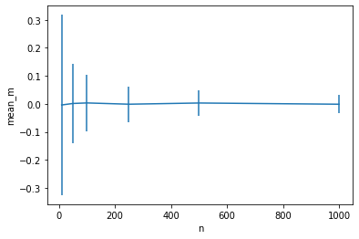

## Data Sphering

**Exercise 9**. Using the function **np.random.multivariate_normal()**, generate a 2D normal distribution with zero mean and covariance matrix $\Sigma = I$. Let the number of samples be 1000. Compute the covariance matrix using **np.cov()** and find the eigenvalues and eigenvectors using **np.linalg.eig()**. Note: the eigenvectors are stored as columns. Run the whole procedure a few times (manually) and take note of the eigenvectors at each run. How can you explain what you observe?

**Exercise 10**. Repeat the previous exercise with $\Sigma = \begin{pmatrix} 3 & 0 \\ 0 & 1 \end{pmatrix}$. Does your observation from the previous exercise still hold? Why or why not? Create a 2D scatter plot of the data (use an equal aspect ratio: **plt.axis('equal')**) and plot the eigenvectors onto the scatter plot. Also plot the eigenvectors scaled by the square root of their corresponding eigenvalues (e.g. as shown below).

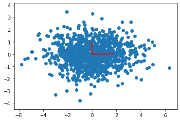

**Exercise 11**. Change $\Sigma$ to $\begin{pmatrix} 3 & -2 \\ -2 & 2 \end{pmatrix}$ and once again create a scatter plot with a plot of the eigenvectors scaled by the square root of their corresponding eigenvalues. Could you have foreseen the result by simply inspecting the covariance matrix?

**Exercise 12**. Suppose a dataset is stored in variable $z$ with $\Sigma = \begin{pmatrix} 3 & -2 \\ -2 & 2 \end{pmatrix}$. And suppose $e$ contains the eigenvectors and $D$ is a diagonal matrix containing the corresponding eigenvalues on the main diagonal. Sphere the data simply using the following line:

**w = z.dot(e).dot(np.linalg.inv(np.sqrt(D)))**

What do you notice? Create two scatter plots superimposed, one for the original data and the other for the sphered data. Make sure you use different colors, and use a proper legend with **plt.legend()**.

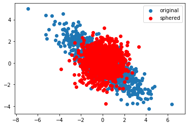

## Non-Parametric Density Estimation

### Parzen Density Estimation

**Exercise 13**. Read in the file 'dataset1D.txt'. The dataset $a$ consists of two classes with 20 objects each (labels not provided). The samples are drawn from a 1D normal distribution. Scikit-learn provides a function for estimating density using kernels, **KernelDensity()** (ie module sklearn.neighbors). Acquaint yourself with the inputs and outputs of this method and use it with default Gaussian kernel to estimate the density over the given dataset while also plotting the 1D scatter plot of the data (hint: these have 0 y-values).

Note: densities are estimated on a grid of points (e.g. as generated by **np.linspace()** with extended margins beyond the minimum and maximum of $a$) and (log) density values are accessible with method `score_samples()` after having fit the kernel model on dataset $a$. A bandwidth of 1 (default) is used in the plot below.

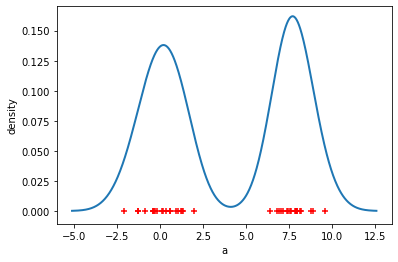

Try different bandwidth values for the kernel. What happens with lower values and higher values. Which kernel width do you think is optimal for this dataset?

To evaluate the fit of a density model to the actual data, an error measure is required. In this case, we may use the log-likelihood defined as:

$LL(x) = ln \left( \prod_i \widehat{p}(x_i) \right) = \sum_i ln(\widehat{p}(x_i))$

If the model fits well, then the log-likelihood should be high. Different kernel widths $h$ result in different models. Thus, using the log-likelihood, we can choose an optimal kernel width $h$ that corresponds to a maximum log-likelihood measure. Note that the log-likelihood must be evaluated on an independent test set; that is, it is not acceptable to evaluate the log-likelihood using the same training set on which the probability density function was fitted which would lead to a biased (optimistic) evaluation.

**Exercise 14**. The file 'dataset1D.txt' contains a training set `trn` and a test set `tst` of equal size randomly sampled from the original distribution that `a` was sampled from. Estimate the Parzen density using the training set and calculate the log-likelihood on the test set for kernel widths $h = [0.1, 0.25, 0.5, 1, 1.5, 2, 3, 4, 5]$. Then plot the log-likelihood curve as a function of $h$. Based on the log-likelihood curve, which value for $h$ would you choose? Does this agree to some extent with your choice using trial and error from the previous exercise? Is there yet another way to improve the assessment of kernel width $h$? If so, describe it.

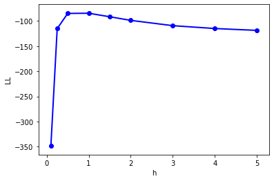

### Nearest Neighbor Density Estimation

**Exercise 15**. Write your own function **knn()** that implements the k-nearest neighbor density estimation method for the 1D case. The function should take in three arguments, a training set `a`, a test set `b` at which to evaluate the density, and a value for `k`. The output should be the density values over `b`. Test your function on 'dataset1D.txt'. Use the dataset $a$ for training, and use a grid over the range of `a` for testing. Try out different values for `k`; which one seems optimal? Hint: **cdist()** from scipy might be useful for obtaining a distance matrix between objects (i.e. from module **scipy.spatial.distance**).

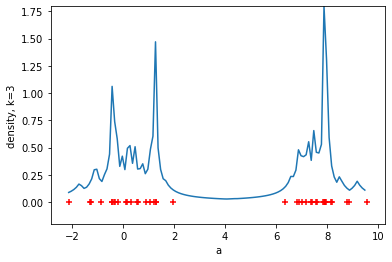